# Makeover Monday - 2020W42

Healthcare Spending

Billy Caughey

2020-10-18

## Introduction

This weeks **Makeover Monday** is based on Healthcare Spending. This topic is a polarizing topic world-wide and is particularly polarizing in the United States. The visual for this week is below.

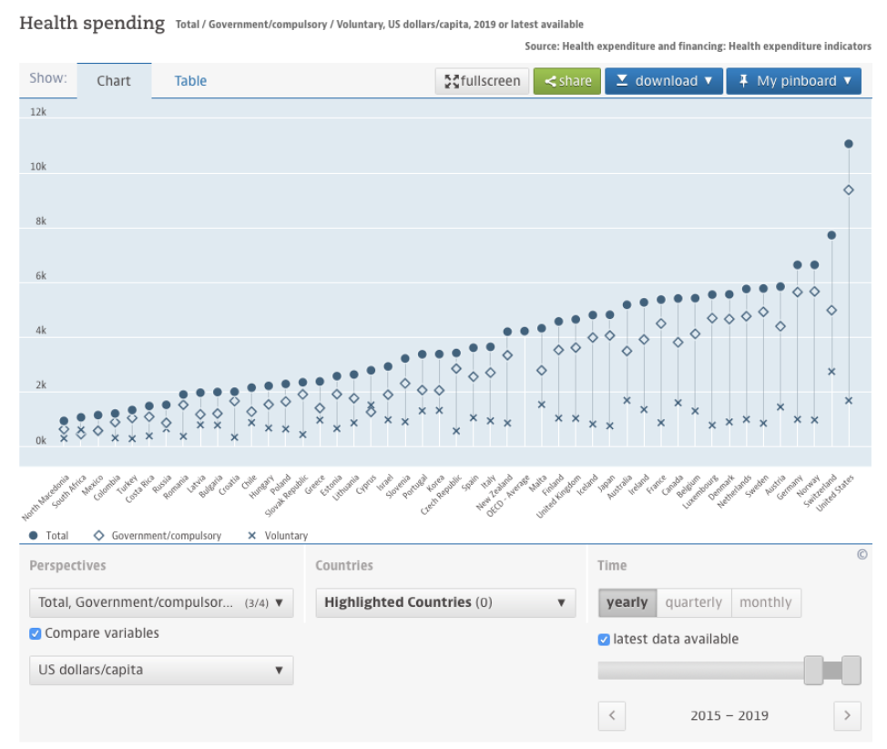

Fig. 1: Makeover Monday - 2020W42 Viz

Like always, there are two main questions asked:

- What works and what doesn't work with this chart?
- How can you make it better?

### What works?

This visual definitely shows the different between countries. The simple use of colors and symbols is very much appreciated. The comparisons between countries is really appreciated.

### What doesn't work?

Another view which needs to be presented is the cost per country and the overall health of each country. If a country spends more than other countries, theorectically, the country which spends more *should* have better health outcomes.

These two views will be presented along with the original view.

## Preprocessing

### Import data

The data for this analysis is housed by [data.world](https://data.world/makeovermonday/2020w42). The simple script below can import the data.

For simplicity sake of this analysis, countries with a 'total', 'govenment/compulsory', and 'voluntary' value in 2019 will be kept in this analysis. This will make collecting population values and health outcomes more doable.

```r
library(tidyverse)

df <- read_csv(file = "https://query.data.world/s/blcux4jkz3n6qywf4zypxxddqqtzrl",
               col_names = c("location", "indicator", "subject", "measure",
                             "frequency", "time", "value", "flag_codes"),
               col_types = "ccccccdc") %>%
    filter(time == "2019",
           measure == "USD_CAP")
```

Now, a simple effort will be taken to determine if any of the values are missing. There are easy ways to do this, but the **Amelia** package has a `missmap` function which shows if there are missing values. If there are missing values in the *value* field, that country it's associated with will be dropped from the analysis.

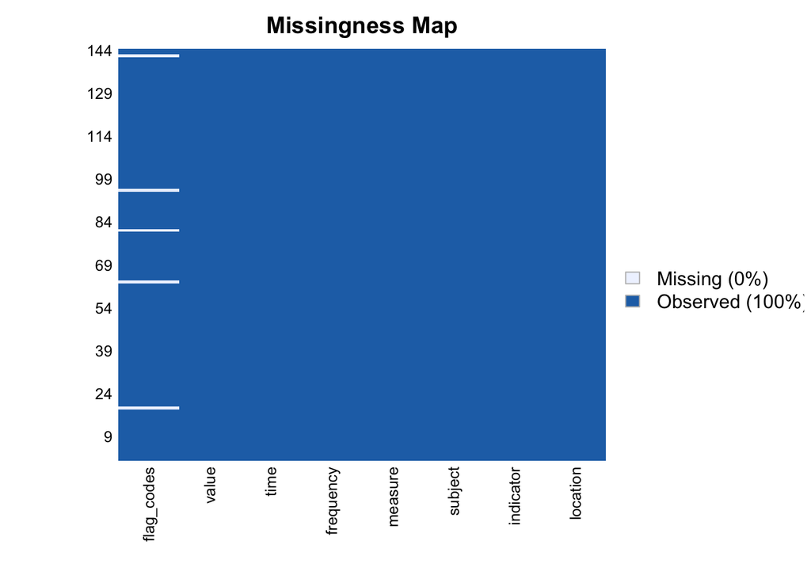

```r
library(Amelia)

missmap(df)
```